# Solutions 7: Intro to Multiple Linear Regression

Author

Affiliation

Adam Spiegler

University of Colorado Denver

## Additional Reading

- [Chapter 3 Linear Model Estimation](https://jfrench.github.io/LinearRegression/linear-model-estimation.html) from *A Progressive Introduction to Linear Models*
- Chapter 4 of *Linear Regression Models: Applications in R* ([link to library ebook](https://go.exlibris.link/Q7wgCRrz))
- Chapter 3 of *Applied Linear Regression* ([link to library ebook](https://go.exlibris.link/69jsQwWW))

# Loading Required Packages

```r
library(tidyverse)
library(plotly)  # for interactive 3d plots
```

# Loading Country Data

[World Development Indicators (WDI)](https://datatopics.worldbank.org/world-development-indicators/) are a comprehensive data set of globally comparable statistics on poverty and development, maintained by the World Bank, providing data on over 1,400 indicators for 217 economies across various themes like health, education, environment, and economy.

The data frame `country` was created using the `WDI` package to import several World Development Indicators from the World Bank Data Bank website. See the Appendix for the code used to create this data frame.

```r
country <- read_csv("https://raw.githubusercontent.com/aspiegler/Applied-Regression/main/Data/country.csv")
head(country)
```

```
# A tibble: 6 × 6
  country             life_exp gdp_per_cap lit_rate fertility land_area
  <chr>                  <dbl>       <dbl>    <dbl>     <dbl>     <dbl>
1 Afghanistan             66.0       2202.     37        4.84    652230
2 Albania                 79.6      23488.     98.5      1.35     27400
3 Algeria                 76.3      17553.     81.4      2.77   2381741
4 Angola                  64.6       8348.     72.4      5.12   1246700
5 Antigua and Barbuda     77.6      33602.     99        1.58       440
6 Argentina               77.4      30176.     97        1.5    2736690
```

## Exploring Variables of Interest

- `life_exp`: Life expectancy at birth (in years) is indicator SP.DYN.LE00.IN.
- `gdp_per_cap`: GDP per capita (in dollars) is indicator NY.GDP.PCAP.PP.CD.
- `lit_rate`: Adult literacy rate (in %) is indicator SE.ADT.LITR.ZS.
- `fertility`: Fertility rate (total births per woman) is indicator SP.DYN.TFRT.IN.
- `land_area`: Land area (in square km) is indicator AG.LND.TOTL.K2.

## Question 1

Explore the `country` data frame and answer questions such as:

- Which 5 countries have the highest life expectancy? Shortest life expectancy?
- Which 5 countries have the highest GDP per capita? Smallest GDP per capita?
- Which 5 countries have the highest literacy rate? Lowest literacy rate?
- Which 5 countries have the highest fertility rate? Lowest fertility rate?
- Which 5 countries have the most land area? Least land area?

**Tip**

The `slice_max()` and `slice_min()` functions from `dplyr` are very useful at answering these types of questions. If you are not familiar with these functions, run `?slice_max` and you will be!

### Solution to Question 1

```r
# countries with max values
slice_max(country, life_exp, n = 5)
```

```
# A tibble: 5 × 6
  country     life_exp gdp_per_cap lit_rate fertility land_area
  <chr>          <dbl>       <dbl>    <dbl>     <dbl>     <dbl>
1 San Marino      85.7      75941.    100       1.15        60
2 Spain           83.9      56926.     99       1.12    499714.
3 Italy           83.7      60847.     99       1.2     295720
4 Malta           83.5      67364.     94.9     1.06       320
5 Korea, Rep.     83.4      52204.     98.8     0.721    97600
```

```r
slice_max(country, gdp_per_cap, n = 5)
```

```
# A tibble: 5 × 6
  country           life_exp gdp_per_cap lit_rate fertility land_area
  <chr>                <dbl>       <dbl>    <dbl>     <dbl>     <dbl>
1 Singapore             82.9     150689.     98       0.97        718
2 Macao SAR, China      83.2     128268.     97.1     0.586        33
3 Qatar                 82.4     126110.     98       1.73      11490
4 Brunei Darussalam     75.3      90007.     97.6     1.75       5270
5 Cayman Islands        80.4      86689.     99       1.53        240
```

```r
slice_max(country, lit_rate, n = 5)
```

```
# A tibble: 8 × 6
  country            life_exp gdp_per_cap lit_rate fertility land_area
  <chr>                 <dbl>       <dbl>    <dbl>     <dbl>     <dbl>
1 Armenia                77.5      22823.      100     1.9       28470
2 Azerbaijan             74.4      25089.      100     1.55      82650
3 Belarus                74.2      33006.      100     1.21     202990
4 Georgia                74.5      28418.      100     1.81      69490
5 Russian Federation     73.3      47405.      100     1.41   16376870
6 San Marino             85.7      75941.      100     1.15         60
7 Ukraine                73.4      18550.      100     0.977    579400
8 Uzbekistan             72.4      11879.      100     3.5      440652
```

```r
slice_max(country, fertility, n = 5)
```

```
# A tibble: 5 × 6
  country                  life_exp gdp_per_cap lit_rate fertility land_area
  <chr>                       <dbl>       <dbl>    <dbl>     <dbl>     <dbl>
1 Somalia                      58.8       1601.     54        6.13    627340
2 Chad                         55.1       2962.     27.3      6.12   1259200
3 Niger                        61.2       2015.     38.1      6.06   1266700
4 Congo, Dem. Rep.             61.9       1710.     80.5      6.05   2267050
5 Central African Republic     57.4       1264.     37.5      6.01    622980
```

```r
slice_max(country, land_area, n = 5)
```

```
# A tibble: 5 × 6
  country            life_exp gdp_per_cap lit_rate fertility land_area
  <chr>                 <dbl>       <dbl>    <dbl>     <dbl>     <dbl>
1 Russian Federation     73.3      47405.    100       1.41   16376870
2 China                  78.0      27105.     97       0.999   9388210
3 Brazil                 75.8      22333.     94.7     1.62    8358140
4 India                  72.0      11159.     77       1.98    2973190
5 Argentina              77.4      30176.     97       1.5     2736690
```

```r
# countries with max values
slice_min(country, life_exp, n = 5)
```

```
# A tibble: 5 × 6
  country                  life_exp gdp_per_cap lit_rate fertility land_area
  <chr>                       <dbl>       <dbl>    <dbl>     <dbl>     <dbl>
1 Nigeria                      54.5       6440.     63.2      4.48    910770
2 Chad                         55.1       2962.     27.3      6.12   1259200
3 Lesotho                      57.4       2998.     82.0      2.69     30360
4 Central African Republic     57.4       1264.     37.5      6.01    622980
5 South Sudan                  57.6       1155.     34.5      3.86    631930
```

```r
slice_min(country, gdp_per_cap, n = 5)
```

```
# A tibble: 5 × 6
  country                  life_exp gdp_per_cap lit_rate fertility land_area
  <chr>                       <dbl>       <dbl>    <dbl>     <dbl>     <dbl>
1 Burundi                      63.7        950.     75.5      4.88     25680
2 South Sudan                  57.6       1155.     34.5      3.86    631930
3 Central African Republic     57.4       1264.     37.5      6.01    622980
4 Somalia                      58.8       1601.     54        6.13    627340
5 Mozambique                   63.6       1700.     60        4.76    786380
```

```r
slice_min(country, lit_rate, n = 5)
```

```
# A tibble: 5 × 6
  country      life_exp gdp_per_cap lit_rate fertility land_area
  <chr>           <dbl>       <dbl>    <dbl>     <dbl>     <dbl>
1 Chad             55.1       2962.     27.3      6.12   1259200
2 Mali             60.4       3309.     31        5.61   1220190
3 Burkina Faso     61.1       2896.     34.5      4.19    273600
4 South Sudan      57.6       1155.     34.5      3.86    631930
5 Afghanistan      66.0       2202.     37        4.84    652230
```

```r
slice_min(country, fertility, n = 5)
```

```
# A tibble: 5 × 6
  country          life_exp gdp_per_cap lit_rate fertility land_area
  <chr>               <dbl>       <dbl>    <dbl>     <dbl>     <dbl>
1 Macao SAR, China     83.2     128268.     97.1     0.586        33
2 Korea, Rep.          83.4      52204.     98.8     0.721     97600
3 Puerto Rico (US)     81.7      50156.     92.4     0.92       8870
4 Singapore            82.9     150689.     98       0.97        718
5 Ukraine              73.4      18550.    100       0.977    579400
```

```r
slice_min(country, land_area, n = 5)
```

```
# A tibble: 5 × 6
  country          life_exp gdp_per_cap lit_rate fertility land_area
  <chr>               <dbl>       <dbl>    <dbl>     <dbl>     <dbl>
1 Macao SAR, China     83.2     128268.     97.1     0.586        33
2 San Marino           85.7      75941.    100       1.15         60
3 Aruba                76.4      44967.     98.0     1.60        180
4 Marshall Islands     66.9       8198.     98       2.92        180
5 Cayman Islands       80.4      86689.     99       1.53        240
```

```r
slice_max(country, country, n=10)
```

```
# A tibble: 10 × 6
   country              life_exp gdp_per_cap lit_rate fertility land_area
   <chr>                   <dbl>       <dbl>    <dbl>     <dbl>     <dbl>
 1 Zimbabwe                 62.8       3922.     89.8      3.72    386850
 2 Zambia                   66.3       4224.     87.5      4.10    743390
 3 Yemen, Rep.              69.3       3164.     54.1      4.59    527970
 4 West Bank and Gaza       65.2       4371.     98        3.31      6025
 5 Viet Nam                 74.6      16386.     96        1.91    313429
 6 Venezuela, RB            72.5      17349.     97.6      2.08    882050
 7 Vanuatu                  71.5       3602.     89.1      3.60     12190
 8 Uzbekistan               72.4      11879.    100        3.5     440652
 9 Uruguay                  78.1      36418.     99        1.41    175020
10 United Arab Emirates     82.9      77959.     98        1.2      71020
```

# Linear Regression Models

**Definition**

A **linear model** is a regression model in which the regression coefficients enter the model linearly. For example:

$$Y = \beta_0 + \beta_1 X_1 + \beta_2 X_2 + \ldots + \beta_p X_p + \epsilon . \tag{1}$$

The model does not need to be linear in predictor variables:

$$Y = \beta_0 + \beta_1 X_1^2 + \beta_2 e^{X_2+X_3^2} + \beta_3 \ln{(X_1X_2X_3)} + \epsilon$$

The $\beta_i$’s are called the **regression coefficients**, and these are unknown parameters we will estimate.

- A **simple linear regression model** has one predictor, $Y = \beta_0 + \beta_1 X + \epsilon$.
- A **multiple linear regression model** has more than one predictor variable.

# Exploring Relations

Suppose we want to explore the following question:

> What is the best way to improve the life expectancy of citizens? Education, wealth, having children and/or space to spread out?

## Revisiting Covariance and Correlation

The **covariance** is one statistic we can use to measure the relation between two variables:

$$\text{Cov}(X,Y) = E \big[ (X - \mu_x)(Y - \mu_y) \big]$$

The **Pearson correlation coefficient** is a normalized measure of the linear association between two variables that results in a value between $-1$ and $1$.

$$\rho_{X,Y} = \frac{\text{Cov}(X,Y)}{\sigma_x \sigma_y}$$

When working with sample data, we denote the correlation coefficient with $r$, and we can interpret the value as follows:

- If $r$ is close to zero, then there not a strong linear association between the two variables.
- If $r$ is positive, there is a positive linear association between the variables.
- If $r$ is negative, there is a negative linear association between the variables.
- The closer the $|r|$ is to $1$, the stronger the linear relationship.

**Caution**

Two variables can very strongly related even though they have $r \approx 0$ if the relation is not linear.

[figure not shown]

Image with Different Correlation Values

## Question 2

Run the code cell below to construct a correlation matrix to compute and compare pairwise correlation. Which other variable seems to have the strongest (positive or negative) correlation with `life_exp`?

```r
cor(country[-1])  # exclude column 1
```

```
               life_exp   gdp_per_cap    lit_rate   fertility     land_area
life_exp     1.00000000  7.055354e-01  0.72859101 -0.82952865 -9.914450e-03
gdp_per_cap  0.70553545  1.000000e+00  0.49785997 -0.60557106 -9.123316e-05
lit_rate     0.72859101  4.978600e-01  1.00000000 -0.75934641  1.907463e-02
fertility   -0.82952865 -6.055711e-01 -0.75934641  1.00000000 -3.059021e-02
land_area   -0.00991445 -9.123316e-05  0.01907463 -0.03059021  1.000000e+00
```

### Solution to Question 2

- Fertility rate has the strongest (negative) linear association with `life_exp`.
- Literacy rate has the strongest (positive) linear association with `life_exp`.

## Scatter Plot Matrix

We can look at the relations using a scatter plot matrix since just because the correlation coefficient only tells us the strength of linear relations. Looking at pairwise scatter plots we may see a strong non-linear relationship and adjust our model accordingly.

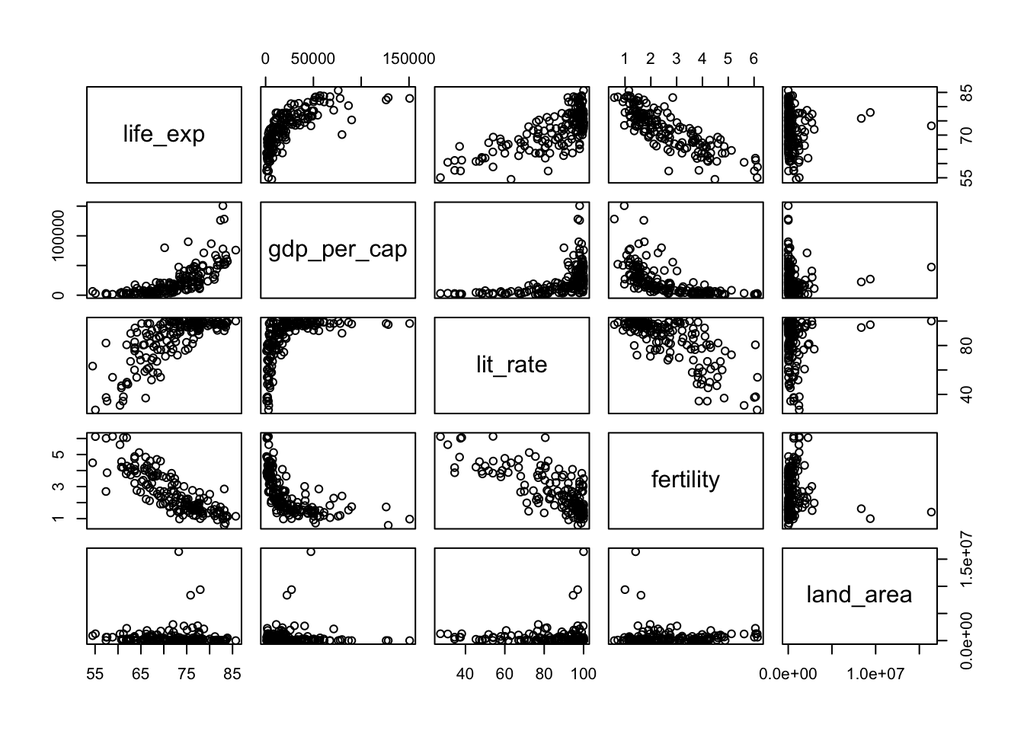

```r
pairs(country[-1])
```

## Question 3

Create a linear model named `life_lm` with `life_exp` as the response and `gdp_per_cap` as the one predictor. Interpret the practical meaning (if possible) of the slope and intercept. Then create a scatter plot with the regression line added.

**Warning**

Be sure to store your linear model to an object called `life_lm` to be consistent with work to follow.

### Solution to Question 3

```r
life_lm <- lm(life_exp ~ gdp_per_cap, data = country)
summary(life_lm)
```

```
Call:
lm(formula = life_exp ~ gdp_per_cap, data = country)

Residuals:
     Min       1Q   Median       3Q      Max
-14.4014  -2.4363   0.6495   3.6141   8.3735

Coefficients:
             Estimate Std. Error t value Pr(>|t|)
(Intercept) 6.764e+01  5.203e-01  130.00   <2e-16 ***
gdp_per_cap 1.892e-04  1.498e-05   12.63   <2e-16 ***
---
Signif. codes:  0 '***' 0.001 '**' 0.01 '*' 0.05 '.' 0.1 ' ' 1

Residual standard error: 4.845 on 161 degrees of freedom
Multiple R-squared:  0.4978,    Adjusted R-squared:  0.4947
F-statistic: 159.6 on 1 and 161 DF,  p-value: < 2.2e-16
```

$$y = 67.64 + 0.0001892$$

- The intercept tells us if a country has $\$0$ gdp per capita, the predicted life expectancy of people in the country is $67.64$ years. This is not particularly useful since there are no such countries.
- For every additional $\$1$ of gdp per capita, life expectancy increases on average by $0.0001892$ years (or $1.657$ hours).
- That sounds a little weird. So we could also say for every additional $\$10,000$ of gdp per capita a country has, life expectancy is increase on average by about $1.892$ years.

```r
hours <- 24 * 365
0.0001892 * hours
```

```
[1] 1.657392
```

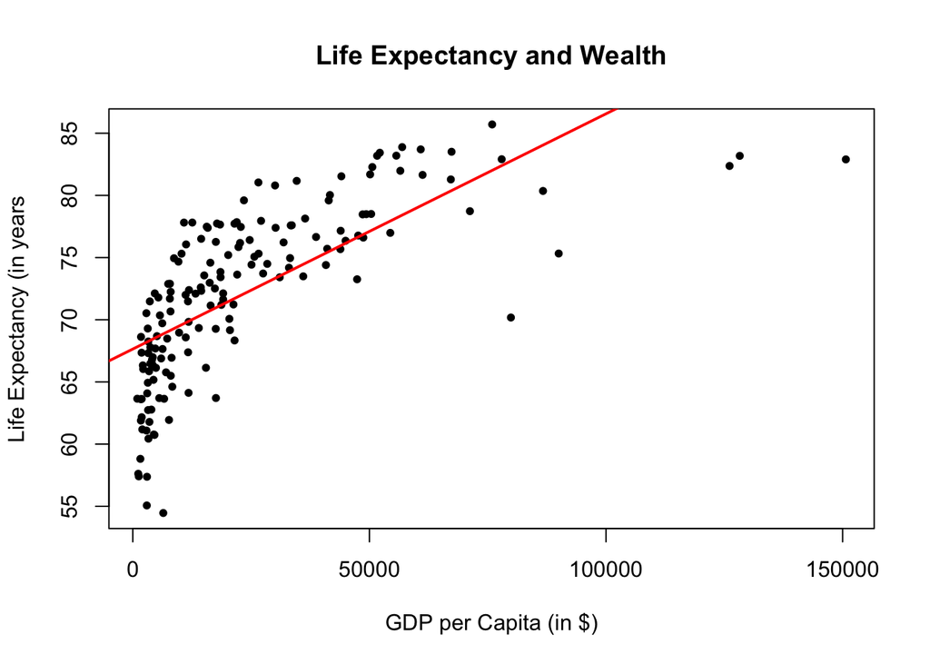

```r
plot(life_exp ~ gdp_per_cap, data = country,
     pch = 20,  # solid points
     main = "Life Expectancy and Wealth",
     xlab = "GDP per Capita (in $)",
     ylab = "Life Expectancy (in years")
abline(life_lm, col = "red", lwd = 2)
```

## Checking Error Assumptions

Recall a simple linear regression model of the form $Y_i = \beta_0 + \beta_1 x_i + \epsilon_i$ has the following key assumptions about the errors of prediction:

- On average, we expect the errors to be zero, $E(\epsilon_i) = 0$ for $i=1, 2, \ldots, n$.
- Homoscedasticity. The errors will all have the same variance, $\text{Var}(\epsilon_i) = \sigma^2$ or $i=1, 2, \ldots, n$.
- The errors are uncorrelated, $\text{Cov}(\epsilon_i, \epsilon_j) = 0$ when $i \ne j$.
- Each $\epsilon_i$ is normally distributed.

$$\large \epsilon_i \sim N(0, \sigma^2) \qquad \text{and} \qquad \text{Cov}(\epsilon_i, \epsilon_j) = 0 \ \ \text{ if } i \ne j.$$

### A New Assumption

We add an additional error assumption for multiple linear regression models.

- **Collinearity**: No combination of the predictor variables are directly interrelated.

## Question 4

Run the code cell below to generate the residuals vs fitted plot for the `life_lm` model created in Question 3. Comment about which error assumptions seem to be satisfied and which do not. Explain how you used to plot to help determine your answers.

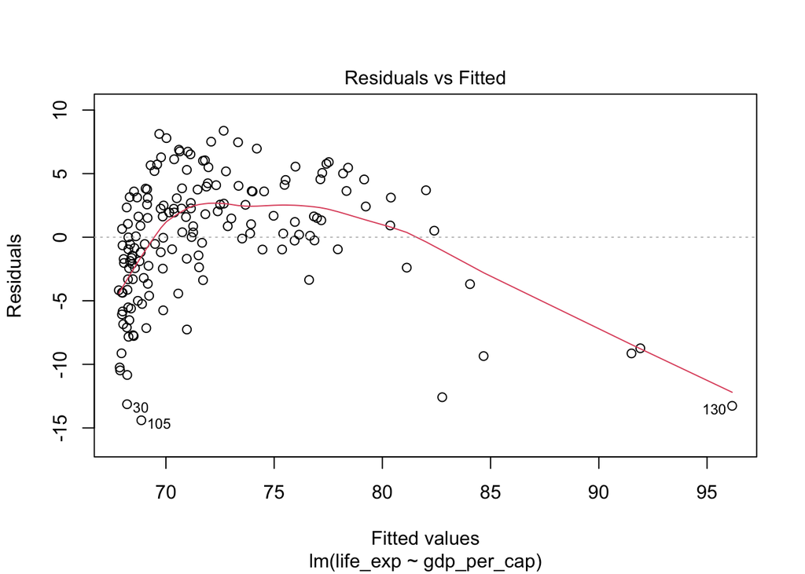

```r
# residuals vs fitted plot
plot(life_lm, which = 1)
```

### Solution to Question 4

- The errors have mean zero assumption is not satisfied.
  - We can tell this by looking at the relation of the red line and the dashed horizontal line.
- The variance of the errors is not constant. The homoscedasticity assumption is not satisfied.
  - The residuals do not appear as a horizontal band with equidistant above and below the dashed horizontal line through 0,
- The assumption about a the model being linear relation does not seem valid since there is an observable pattern in the residuals.
  - For smaller fitted values on the left, the residuals are mostly negative.
  - For larger fitted values on the right, the residuals are mostly negative.
  - For fitted values in between, the residuals are mostly positive.
  - This would not be the case if the relation is linear.
- The assumption about interdependence of residuals does not seem to be satisfied due to the pattern of the residuals noted above.
- The normality assumption we cannot judge from this plot, but a qq-plot would help.

```r
# countries the model provides the worst predictions
country[c(30, 105, 130),]
```

```
# A tibble: 3 × 6
  country   life_exp gdp_per_cap lit_rate fertility land_area
  <chr>        <dbl>       <dbl>    <dbl>     <dbl>     <dbl>
1 Chad          55.1       2962.     27.3      6.12   1259200
2 Nigeria       54.5       6440.     63.2      4.48    910770
3 Singapore     82.9     150689.     98        0.97       718
```

## A First Look at $R^2$

In the output of `lm()`, the $R^2$ value corresponding to the model is computed. For example, `life_lm` has an $R^2$ value of $0.4978$. Informally, we can interpret this as about $50\%$ of the variability in `life_exp` is explained by `gdp_per_cap`. The other $50\%$, who knows?

# Applying a Transformation

In the code cell below, we take an initial look at the relation between `gdp_per_cap` and `life_exp`.

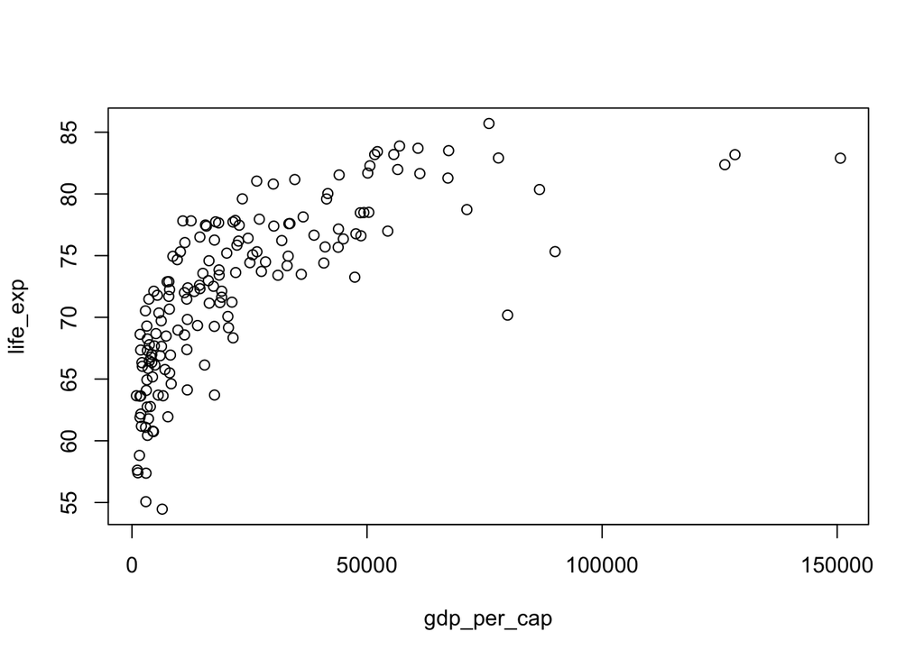

```r
plot(life_exp ~ gdp_per_cap, country)
```

There does seem to be a positive relation between the two, but maybe a linear relationship with `gdp_per_cap` is not the best model. There are a couple of very wealthy countries that appear far out on the right, and that makes it tricky to see all of the rest of the countries smushed together. In the code cell below apply the natural log (`log()`) to `gdp_per_cap`. After running the code cell below, `country` will now have a variable `log_gdp`, the natural log of GDP per capita, and the variable `gdp_per_cap` is dropped since it is now redundant.

```r
country <- country |>
  mutate(log_gdp = log(gdp_per_cap), .before = gdp_per_cap) |>
  select(-gdp_per_cap)  # remove gdp_per_cap
country
```

```
# A tibble: 163 × 6
   country             life_exp log_gdp lit_rate fertility land_area
   <chr>                  <dbl>   <dbl>    <dbl>     <dbl>     <dbl>
 1 Afghanistan             66.0    7.70     37        4.84    652230
 2 Albania                 79.6   10.1      98.5      1.35     27400
 3 Algeria                 76.3    9.77     81.4      2.77   2381741
 4 Angola                  64.6    9.03     72.4      5.12   1246700
 5 Antigua and Barbuda     77.6   10.4      99        1.58       440
 6 Argentina               77.4   10.3      97        1.5    2736690
 7 Armenia                 77.5   10.0     100        1.9      28470
 8 Aruba                   76.4   10.7      98.0      1.60       180
 9 Azerbaijan              74.4   10.1     100        1.55     82650
10 Bahrain                 81.3   11.1      98        1.82       790
# ℹ 153 more rows
```

The correlation coefficient between `life_exp` and `log_gdp` increased from $0.7055$ to $0.8414$, and it is now the variable with the strongest linear relation among the other possible predictors.

```r
cor(country[-1])  # exclude column 1
```

```
             life_exp     log_gdp    lit_rate   fertility   land_area
life_exp   1.00000000  0.84137509  0.72859101 -0.82952865 -0.00991445
log_gdp    0.84137509  1.00000000  0.73049476 -0.82079902  0.05212939
lit_rate   0.72859101  0.73049476  1.00000000 -0.75934641  0.01907463
fertility -0.82952865 -0.82079902 -0.75934641  1.00000000 -0.03059021
land_area -0.00991445  0.05212939  0.01907463 -0.03059021  1.00000000
```

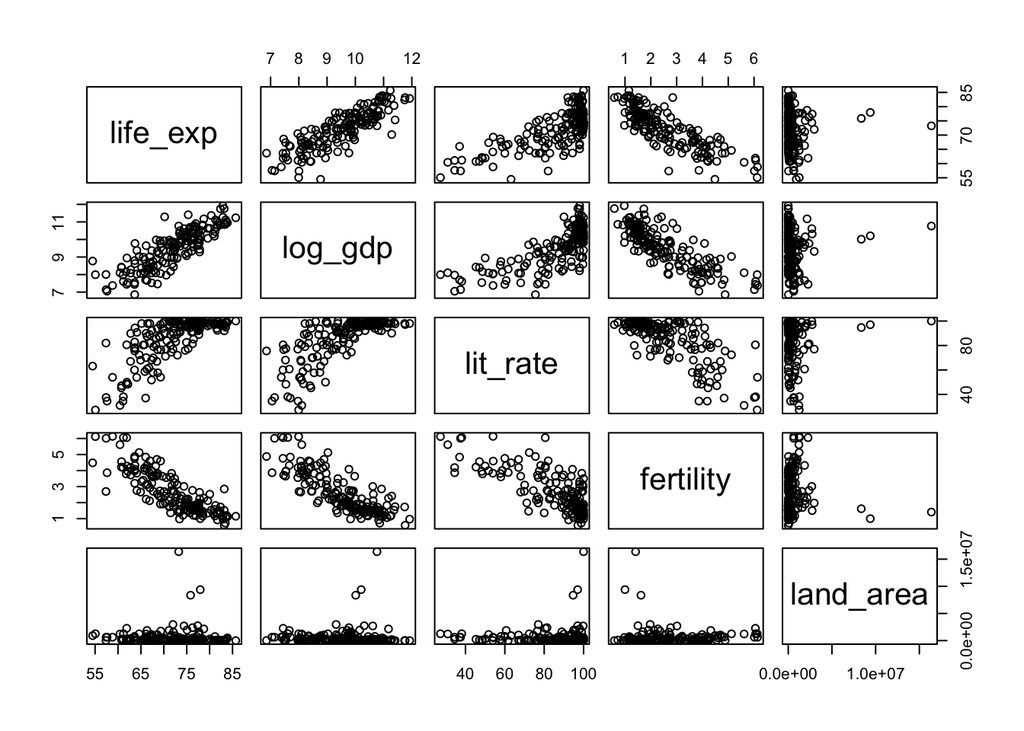

```r
pairs(country[-1])  # exclude column 1
```

## Question 5

Create a linear model named `life_log_lm` with `life_exp` as the response and `log_gdp` as the one predictor. Interpret the practical meaning (if possible) of the slope and intercept. Then create a scatter plot with the regression line added.

**Warning**

Be sure to store your linear model to an object called `life_log_lm` to be consistent with work to follow.

### Solution to Question 5

```r
life_log_lm <- lm(life_exp ~ log_gdp, data = country)
summary(life_log_lm)
```

```
Call:
lm(formula = life_exp ~ log_gdp, data = country)

Residuals:
     Min       1Q   Median       3Q      Max
-13.9428  -2.1461   0.0654   2.7845   6.8025

Coefficients:
            Estimate Std. Error t value Pr(>|t|)
(Intercept)  24.3586     2.4362   9.999   <2e-16 ***
log_gdp       5.0222     0.2542  19.754   <2e-16 ***
---
Signif. codes:  0 '***' 0.001 '**' 0.01 '*' 0.05 '.' 0.1 ' ' 1

Residual standard error: 3.695 on 161 degrees of freedom
Multiple R-squared:  0.7079,    Adjusted R-squared:  0.7061
F-statistic: 390.2 on 1 and 161 DF,  p-value: < 2.2e-16
```

$$y = 24.3586 + 5.0222 \ln{(x)}$$

- The intercept tells us if a country has $\$1$ (where $\ln{(\text{gdp\_per\_cap})}$) gdp per capita, the predicted life expectancy of people in the country is $24.36$ years. This is not particularly useful since there are no such countries.
- A $1\%$ increase in `gdp_per_cap` is equivalent to multiplying $1.01 $ `gdp_per_cap`.
- Such a change gives

$$5.022 \ln{(1.01 X)} = 5.022 (\ln{1.01} + \ln{X}) = 5.022\ln{1.01} + 5.022\ln{X}$$

**Note**

In general, we can interpret the slope $\hat{\beta}_1$ in a **linear-log model** of the form $Y = \hat{\beta}_0 + \hat{\beta}_1 \log{X}$ as follows:

- For each $1\%$ increase in $X$, the response $Y$ increases on average by $0.01 \cdot \hat{\beta}_1$.

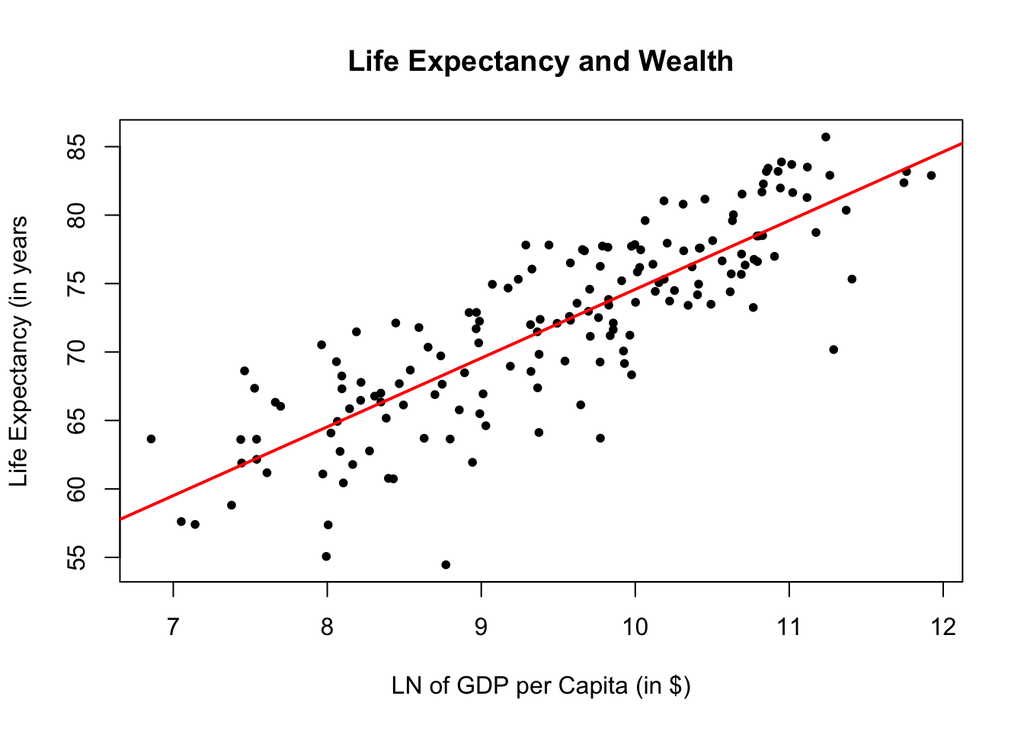

```r
plot(life_exp ~ log_gdp, data = country,
     pch = 20,  # solid points
     main = "Life Expectancy and Wealth",
     xlab = "LN of GDP per Capita (in $)",
     ylab = "Life Expectancy (in years")
abline(life_log_lm, col = "red", lwd = 2)
```

## Reassessing the Fit

The $R^2$ value for our updated model using `log_gdp` is now $R^2 = 0.7079$. Thus, about $70\%$ of the variability in `life_exp` is explained by `log_gdp` which is a big improvement from $R^2 = 0.4978$ in a previous model.

## Question 6

Run the code cell below to generate the residuals vs fitted plot for the `life_log_lm` model. Comment about which error assumptions seem to be satisfied and which do not. Explain how you used to plot to help determine your answers.

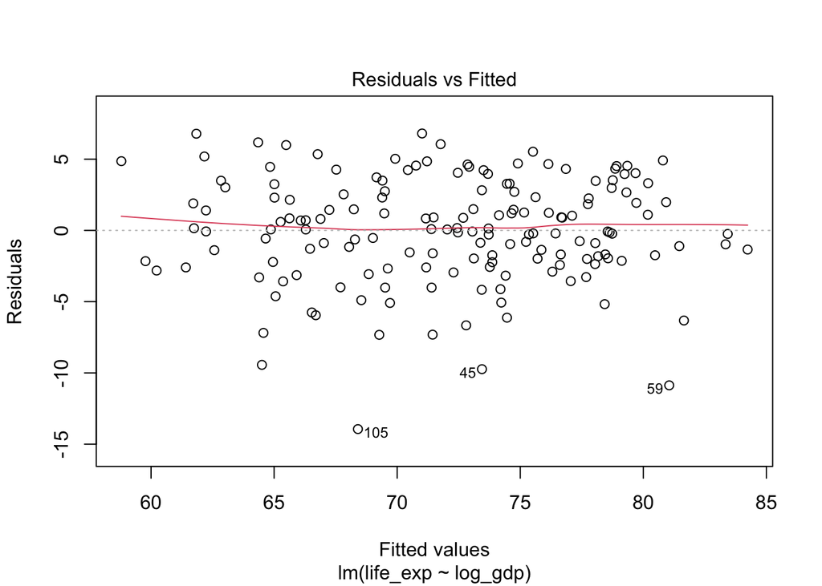

```r
# residuals vs fitted plot
plot(life_log_lm, which = 1)
```

### Solution to Question 6

- The errors have mean zero assumption is satisfied.
  - We can tell this by seeing the red line is pretty closely lined up with the dashed horizontal line.
- The variance of the errors is for the most part constant. The homoscedasticity assumption is satisfied.
  - The residuals do appear as a horizontal band with equidistant above and below the dashed horizontal line through 0.
  - There are a few observations that bucked this trend listed in the code cell below that we could investigate further.
- The assumption about interdependence of residuals does seem to be satisfied since there is no observable pattern in the residuals.
- The normality assumption we cannot judge from this plot, but a qq-plot would help.

```r
# countries with the least accurate predictions
country[c(45, 59, 105), ]
```

```
# A tibble: 3 × 6
  country           life_exp log_gdp lit_rate fertility land_area
  <chr>                <dbl>   <dbl>    <dbl>     <dbl>     <dbl>
1 Equatorial Guinea     63.7    9.77     94.4      4.08     28050
2 Guyana                70.2   11.3      90.0      2.41    196850
3 Nigeria               54.5    8.77     63.2      4.48    910770
```

## Question 7

Determine whether each of the models below is a linear model. For the model(s) that are not linear, can you transform the model into a linear model?

1. $\displaystyle Y = \beta_0 + \beta_1 \left( X_1X_2X_3 \right) + \beta_2 e^{X_1^2+X_2^2+X_3^2} + \beta_3 \ln{(X_3)} + \epsilon$
2. $\displaystyle Y = \beta_0 \left(X_1^{\beta_1}+ X_2^{\beta_2} + X_3^{\beta_3} \right) + \epsilon$
3. $\displaystyle Y = \beta_0 \left(X_1^{\beta_1}X_2^{\beta_2} X_3^{\beta_3} \right) \epsilon$

### Solution to Question 7

1. Yes, linear in regression coefficients.
2. No, the regression coefficients are in power of exponents. We cannot transform this into a linear model since the addition of $\epsilon$ does not work well with properties of log’s.
3. No, the regression coefficients are in power of exponents, but we can transform the model into a linear model by applying a log (natural log) transformation to the response $Y$. In the work below we type $\log{}$ which actually means $\ln{}$.

$$\begin{align}
\log{(Y)} &= \log{ \bigg( \beta_0 \left(X_1^{\beta_1}X_2^{\beta_2} X_3^{\beta_3} \right) \epsilon \bigg)}\\
&= \log{ ( \beta_0 )} + \beta_1 \log{(X_1)} + \beta_1 \log{(X_1)} + \beta_3 \log{(X_3)} + \log{(\epsilon)}
\end{align}$$

## Multiple Linear Regression Models

A **multiple linear regression** model is a linear regression model with more than one predictor $X_i$ and a single response variable $Y$. In general, we include an intercept term as a predictor, so if there are $p$ predictor variables, our model has $p+1$ regression coefficients,

$$Y = \beta_0 + \beta_1 X_1 + \beta_2 X_2 + \ldots + \beta_p X_p + \epsilon .$$

# Revisiting Country Data

`life_exp` of a country likely depends on many factors. We do not need to pick the one variable that has the strongest linear relation. Why see how both `fertility` rate and `log_gdp` values are associated with `life_exp`.

- Let $X_1$ denote the natural log of a country’s GDP per capita. Our sample is stored in `log_gdp`.
- Let $X_2$ denote the fertility rate of a country. Our sample is stored in `fertility`.
- We consider one response variable $Y$ which is a country’s `life_exp`.

Our linear model is now of the form:

$$Y = \beta_0 + \beta_1 X_1 + \beta_2 X_2 + \epsilon .$$

The $i^{\text{th}}$ observation in our sample consists of a pair of observed values we denote $x_{i1}$ and $x_{i2}$ (for the observed values of $X_1$ and $X_2$, respectively), and a corresponding observed value for the response variable $y_i$,

$$(\text{log}\_\text{gdp}, \text{ fertility} , \text{ life}\_\text{exp}) = (x_{i1}, x_{i2}, y_i).$$
We can plot the sample in $\mathbb{R}^3$.

```r
#library(plotly)
plot_ly(country, x=~log_gdp, y=~fertility,
        z=~life_exp, type="scatter3d",
        mode="markers")
```

[interactive chart not shown]

The regression “line” is the 2-dimensional flat plane which we can embed in $\mathbb{R}^3$ that minimizes

$$RSS(\beta_0, \beta_1, \beta_2) = \sum_{i=1}^n \left( y_i - \hat{y}_i \right) = \sum_{i=1}^n \big( y_i - (\beta_0 + \beta_1 x_{i1} + \beta_2 x_{i2}) \big)$$

[interactive chart not shown]

## Question 8

Construct a simple linear regression model named `life_fert_lm` with `life_exp` as the response variable and `fertility` as the only predictor. If possible, interpret the practical meaning of the slope and intercept.

**Warning**

Be sure to store your linear model to an object called `life_fert_lm` to be consistent with work to follow.

### Solution to Question 8

```r
life_fert_lm <- lm(life_exp ~ fertility, country)
summary(life_fert_lm)
```

```
Call:
lm(formula = life_exp ~ fertility, data = country)

Residuals:
    Min      1Q  Median      3Q     Max
-14.376  -2.534   0.269   2.571  12.135

Coefficients:
            Estimate Std. Error t value Pr(>|t|)
(Intercept)  83.6811     0.6814  122.81   <2e-16 ***
fertility    -4.4283     0.2350  -18.85   <2e-16 ***
---
Signif. codes:  0 '***' 0.001 '**' 0.01 '*' 0.05 '.' 0.1 ' ' 1

Residual standard error: 3.818 on 161 degrees of freedom
Multiple R-squared:  0.6881,    Adjusted R-squared:  0.6862
F-statistic: 355.2 on 1 and 161 DF,  p-value: < 2.2e-16
```

$$\text{life\_exp} = 83.6811 - 4.4283 \cdot (\text{fertility})$$

- The intercept tells us if a country has a fertility rate of 0 births per family, the predicted life expectancy of people in the country is $83.68$ years. This is not particularly useful since there are no such countries.
- For every additional 1 child born per family, life expectancy decreases on average by $4.43$ years.

## Comparing Simple Models with Multiple Regression Model

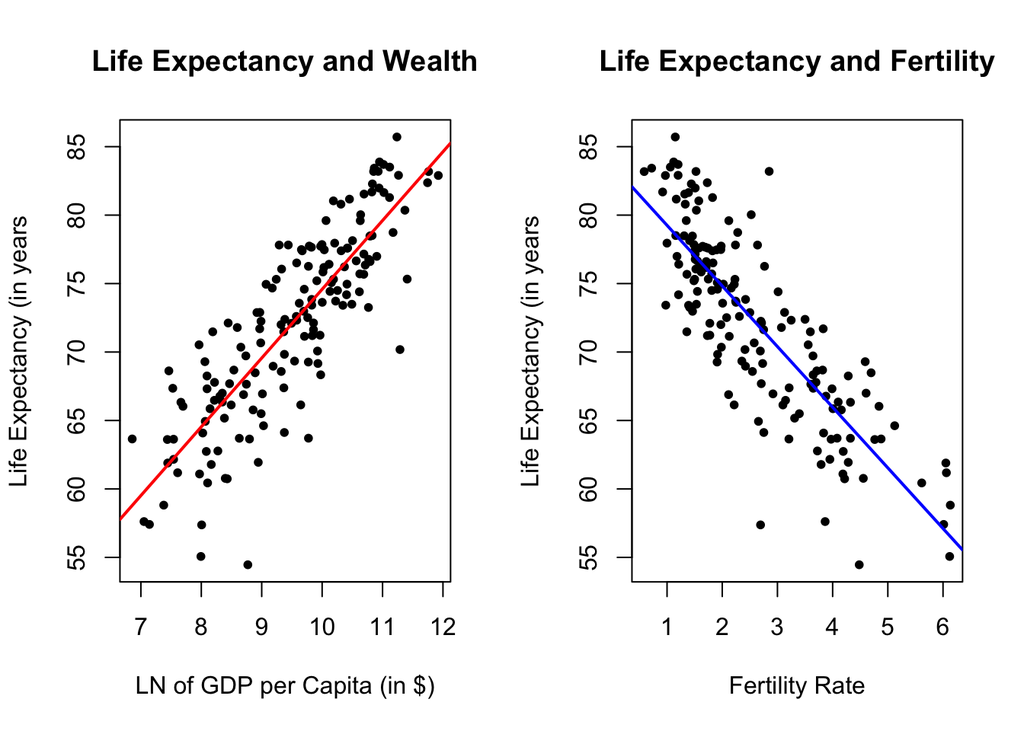

```r
par(mfrow = c(1, 2)) # arrange plots in 1 by 2 array

plot(life_exp ~ log_gdp, data = country,
     pch = 20,  # solid points
     main = "Life Expectancy and Wealth",
     xlab = "LN of GDP per Capita (in $)",
     ylab = "Life Expectancy (in years")
abline(life_log_lm, col = "red", lwd = 2)


plot(life_exp ~ fertility, country,
     pch = 20,  # solid points
     main = "Life Expectancy and Fertility",
     xlab = "Fertility Rate",
     ylab = "Life Expectancy (in years")
abline(life_fert_lm, col = "blue", lwd = 2)
```

## Question 9

Construct a multiple linear regression model name `multi_lm` with `life_exp` as the response variable that is associated with two predictors, `log_gdp` and `fertility`. If possible, interpret the practical meaning of the values of the slopes and intercept.

### Solution to Question 9

```r
multi_lm <- lm(life_exp ~ log_gdp + fertility, data = country)
summary(multi_lm)
```

```
Call:
lm(formula = life_exp ~ log_gdp + fertility, data = country)

Residuals:
     Min       1Q   Median       3Q      Max
-11.2304  -2.1733  -0.0251   2.6648   7.4590

Coefficients:
            Estimate Std. Error t value Pr(>|t|)
(Intercept)  50.1294     4.5943  10.911  < 2e-16 ***
log_gdp       2.9361     0.3987   7.364 8.90e-12 ***
fertility    -2.2730     0.3566  -6.374 1.88e-09 ***
---
Signif. codes:  0 '***' 0.001 '**' 0.01 '*' 0.05 '.' 0.1 ' ' 1

Residual standard error: 3.31 on 160 degrees of freedom
Multiple R-squared:  0.7671,    Adjusted R-squared:  0.7642
F-statistic: 263.4 on 2 and 160 DF,  p-value: < 2.2e-16
```

$$y = 50.1294 + 2.9361 x_1 - 2.2730 x_2 .$$

- The intercept tells us if a country has $\$0$ gdp per capita and a fertility rate of 0 births per family, then the predicted life expectancy of people in the country is $50.13$ years. This is not particularly useful since there are no such countries.
- **If we hold all other variables constant**, a $1\%$ increase in `gdp_per_cap` leads, on average, to an approximate increase in `life_exp` by $0.0294$ years.
- **If we hold all other variables constant**, for every additional 1 child born per family, life expectancy decreases on average by $2.27$ years.

## Question 10

Are the coefficients in the multiple regression model the same or different from the coefficients in each of the simple linear regression models `life_log_lm` and `life_fert_lm`. Explain why the either remain approximately the same or whether the values have changed more substantially.

### Solution to Question 10

The regression coefficients have changed since the predictor variables are not completely independent from each other.

```r
head(country)
```

```
# A tibble: 6 × 6
  country             life_exp log_gdp lit_rate fertility land_area
  <chr>                  <dbl>   <dbl>    <dbl>     <dbl>     <dbl>
1 Afghanistan             66.0    7.70     37        4.84    652230
2 Albania                 79.6   10.1      98.5      1.35     27400
3 Algeria                 76.3    9.77     81.4      2.77   2381741
4 Angola                  64.6    9.03     72.4      5.12   1246700
5 Antigua and Barbuda     77.6   10.4      99        1.58       440
6 Argentina               77.4   10.3      97        1.5    2736690
```

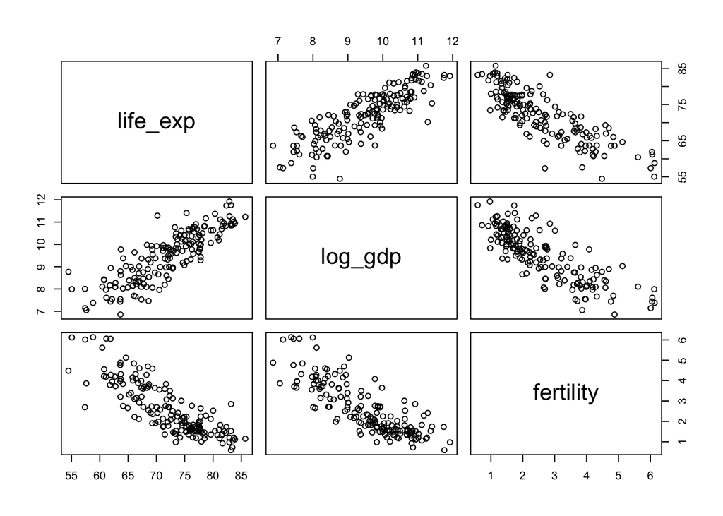

```r
pairs(country[c(2, 3, 5)])
```

**Tip**

The predictors variables are not independent of one another, but, in a multiple linear regression model, they are interpreted as independently predicting the response variable (though in some models we may examine their joint association with the response, and we’ll discuss *interaction* terms later).

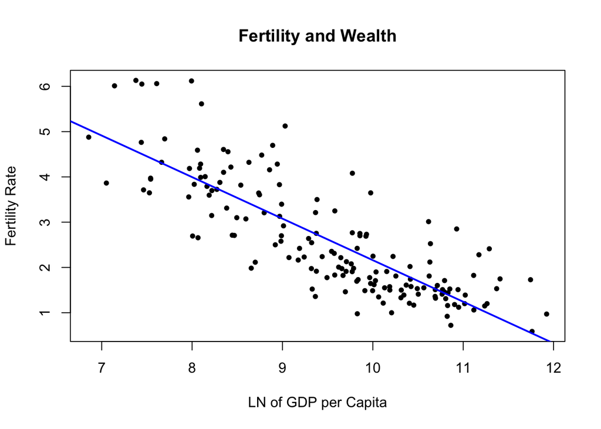

```r
fert_gdp_lm <- lm(fertility ~ log_gdp, data = country)

plot(fertility ~ log_gdp, data = country,
     pch = 20,  # solid points
     main = "Fertility and Wealth",
     xlab = "LN of GDP per Capita",
     ylab = "Fertility Rate")
abline(fert_gdp_lm, col = "blue", lwd = 2)
```

## Marginal Plot of Predictors

**Marginal plots** compare the relation between another possible predictor added to the model and the response variable, ignoring all other predictors. For example, in the model and plot below, we compare the values of `fertility` with the response `life_exp`.

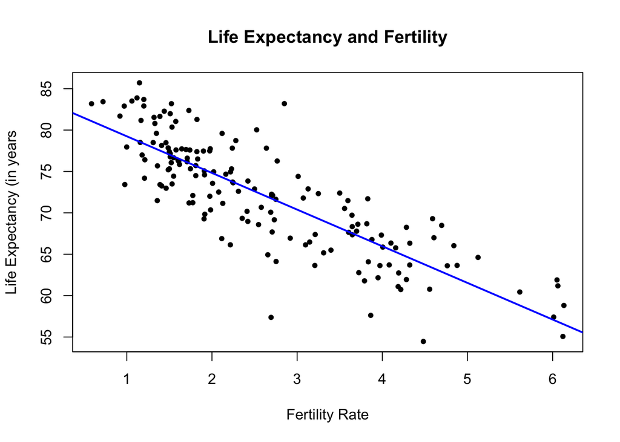

```r
plot(life_exp ~ fertility, country,
     pch = 20,  # solid points
     main = "Life Expectancy and Fertility",
     xlab = "Fertility Rate",
     ylab = "Life Expectancy (in years")
abline(life_fert_lm, col = "blue", lwd = 2)
```

## Added-Variable Plot for Predictors

Residuals measure the variation in a response variable that is not explained by a predictor variable. The remaining variation may be associated with another predictor.

**Added-value plots** compare residuals from models to help us see the effect of adding `fertility` to model that already includes `log_gdp`.

1. Find a simple linear regression model for `life_exp` on the first regressor `log_gdp`.
2. Find a simple linear regression model for the second regressor `fertility` on the first regressor `log_gdp`.
3. The added-variable plot is of the unexplained part (residuals) of `life_exp` from the `log_gdp` model (1) on the unexplained part of `fertility` from model (2).
- A strong linear relationship indicates the new predictor does account for some of the remaining variability in the response variable.
- If the points are scattered with no discernible pattern, the variable doesn’t add significant value to the model.
- If the added-value plot shows a stronger linear relation than the marginal plot, then the two predictor variables do act jointly to explain extra variation.
- If the two graphs have similar variation about the regression line, then the total explained variability by including both predictors is less than the additive amount.

**Note**

The slopes for the coefficient for `fertility` in the multiple linear regression model and the added-value model are identical because they represent the same thing: the shared variability between `life_exp` and `fertility` that does not involve `log_gdp`.

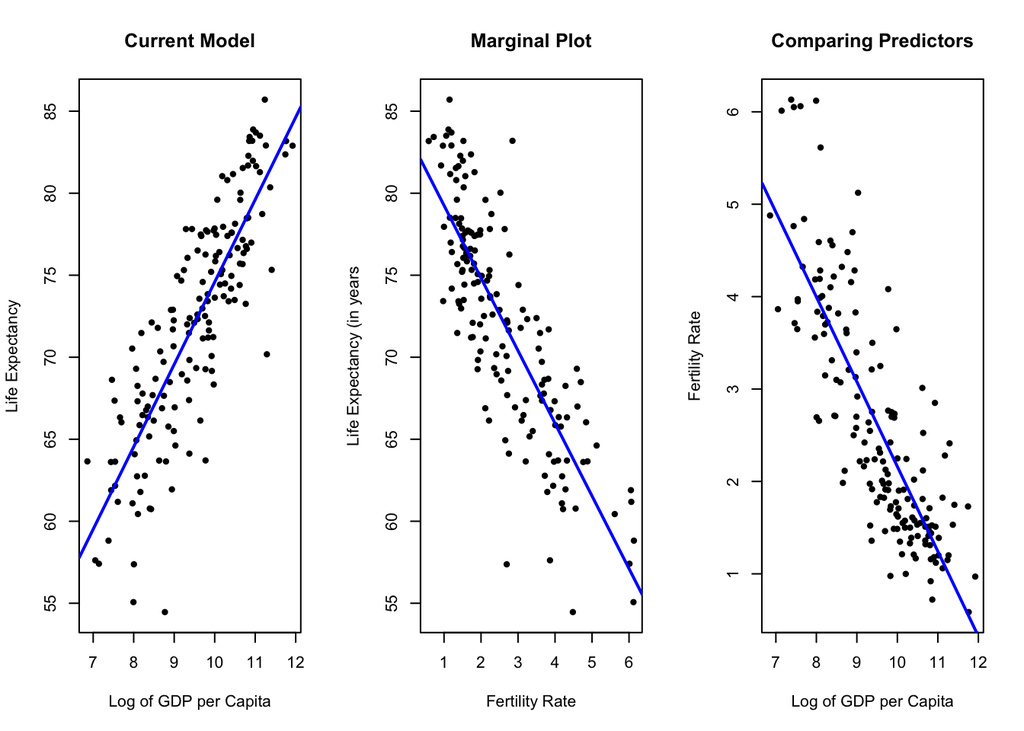

```r
par(mfrow = c(1, 3))

plot(life_exp ~ log_gdp, country,
     pch = 20,  # solid points
     main = "Current Model",
     xlab = "Log of GDP per Capita",
     ylab = "Life Expectancy")
abline(life_log_lm, col = "blue", lwd = 2)

plot(life_exp ~ fertility, country,
     pch = 20,  # solid points
     main = "Marginal Plot",
     xlab = "Fertility Rate",
     ylab = "Life Expectancy (in years")
abline(life_fert_lm, col = "blue", lwd = 2)

plot(fertility ~ log_gdp, country,
     pch = 20,  # solid points
     main = "Comparing Predictors",
     xlab = "Log of GDP per Capita",
     ylab = "Fertility Rate")
abline(fert_gdp_lm, col = "blue", lwd = 2)
```

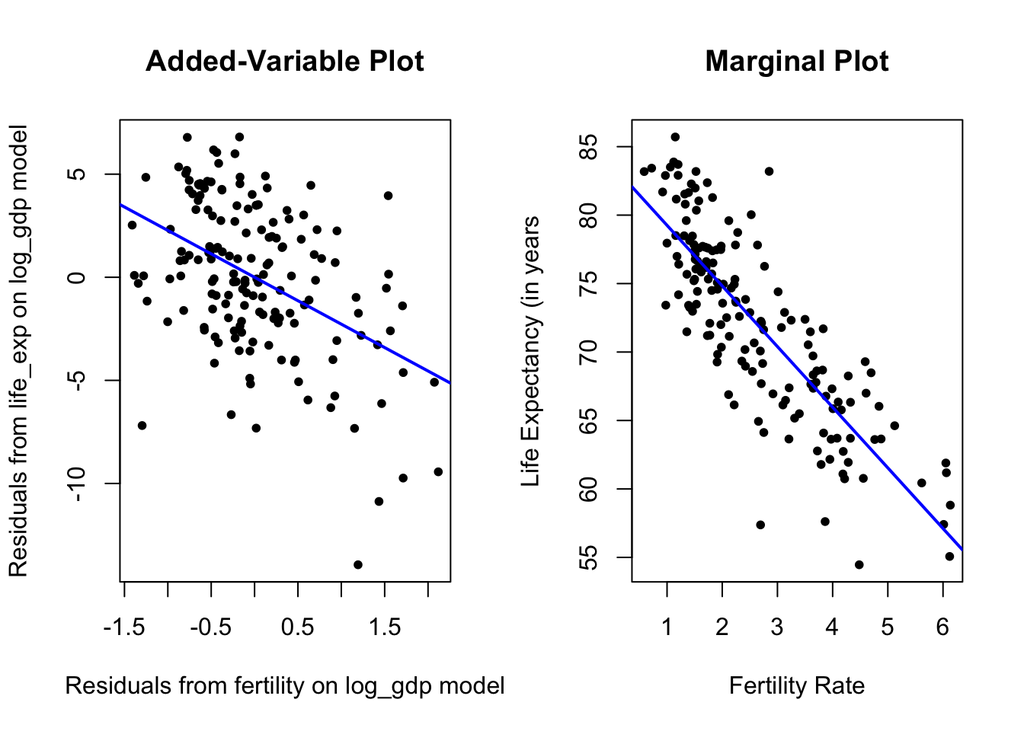

```r
# model for fertility on the first regressor log_gdp.
fert_gdp_lm <- lm(fertility ~ log_gdp, data = country)

par(mfrow = c(1, 2))

resid1 <- residuals(life_log_lm)  # residuals from first model
resid2 <- residuals(fert_gdp_lm)  # residuals from marginal model
added_val <- data.frame(a = resid1, b = resid2)
added_val_lm <- lm(resid1 ~ resid2, data = added_val)  # model of residuals
#summary(added_val_lm)



plot(resid1 ~ resid2, data = added_val,
     pch = 20,  # solid points
     main = "Added-Variable Plot",
     xlab = "Residuals from fertility on log_gdp model",
     ylab = "Residuals from life_exp on log_gdp model")
abline(added_val_lm, col = "blue", lwd = 2)


plot(life_exp ~ fertility, country,
     pch = 20,  # solid points
     main = "Marginal Plot",
     xlab = "Fertility Rate",
     ylab = "Life Expectancy (in years")
abline(life_fert_lm, col = "blue", lwd = 2)
```

```r
summary(added_val_lm)
```

```
Call:
lm(formula = resid1 ~ resid2, data = added_val)

Residuals:
     Min       1Q   Median       3Q      Max
-11.2304  -2.1733  -0.0251   2.6648   7.4590

Coefficients:
              Estimate Std. Error t value Pr(>|t|)
(Intercept)  3.422e-16  2.584e-01   0.000        1
resid2      -2.273e+00  3.555e-01  -6.394 1.67e-09 ***
---
Signif. codes:  0 '***' 0.001 '**' 0.01 '*' 0.05 '.' 0.1 ' ' 1

Residual standard error: 3.3 on 161 degrees of freedom
Multiple R-squared:  0.2025,    Adjusted R-squared:  0.1976
F-statistic: 40.89 on 1 and 161 DF,  p-value: 1.672e-09
```

```r
summary(multi_lm)
```

```
Call:
lm(formula = life_exp ~ log_gdp + fertility, data = country)

Residuals:
     Min       1Q   Median       3Q      Max
-11.2304  -2.1733  -0.0251   2.6648   7.4590

Coefficients:
            Estimate Std. Error t value Pr(>|t|)
(Intercept)  50.1294     4.5943  10.911  < 2e-16 ***
log_gdp       2.9361     0.3987   7.364 8.90e-12 ***
fertility    -2.2730     0.3566  -6.374 1.88e-09 ***
---
Signif. codes:  0 '***' 0.001 '**' 0.01 '*' 0.05 '.' 0.1 ' ' 1

Residual standard error: 3.31 on 160 degrees of freedom
Multiple R-squared:  0.7671,    Adjusted R-squared:  0.7642
F-statistic: 263.4 on 2 and 160 DF,  p-value: < 2.2e-16
```

# Appendix: Creating `country` Data Frame

## Importing World Development Indicators

See [WDI help documentation](https://cran.r-project.org/web/packages/WDI/WDI.pdf).

```r
library(WDI)  # import world development indicators
```

```r
# import literacy rate country data
lit <- WDI(country = "all",
  indicator = "SE.ADT.LITR.ZS",  # Literacy rate  (% of pop above 15)
  latest = 1 #returns most recent non-empty value
)
```

```r
# import life expectancy
health <- WDI(country = "all",
  indicator = "SP.DYN.LE00.IN",  # Life Expectancy in (years)
  latest = 1 #returns most recent non-empty value
)
```

```r
# import land area
area <- WDI(country = "all",
  indicator = "AG.LND.TOTL.K2",  # Land Area (sq.km)
  latest = 1 #returns most recent non-empty value
)
```

```r
# import gdp per capita
wealth <- WDI(country = "all",
  indicator = "NY.GDP.PCAP.PP.CD",  # GDP per cap (ppp)
  latest = 1 #returns most recent non-empty value
)
```

```r
# import fertility rate data
fertility <- WDI(country = "all",
  indicator = "SP.DYN.TFRT.IN",  # fertility rate, children per family
  latest = 1 #returns most recent non-empty value
)
```

## Cleaning Up the Data

```r
# find row index of Afghanistan
lit_start <- which(lit$country == "Afghanistan")
health_start <- which(health$country == "Afghanistan")
area_start <- which(area$country == "Afghanistan")
wealth_start <- which(wealth$country == "Afghanistan")
fertility_start <- which(fertility$country == "Afghanistan")
```

```r
lit_clean <- lit |>
  slice(lit_start:n()) |>  # keep countries only (not aggregates)
  select(country, country_code = iso3c, year_lit = year, lit_rate = SE.ADT.LITR.ZS)
lit_clean
```

```r
health_clean <- health |>
  slice(health_start:n()) |>  # keep countries only (not aggregates)
  select(country, country_code = iso3c, year_health = year, life_exp = SP.DYN.LE00.IN)
health_clean
```

```r
area_clean <- area |>
  slice(area_start:n()) |>  # keep countries only (not aggregates)
  select(country, country_code = iso3c, year_area = year, land_area = AG.LND.TOTL.K2)
area_clean
```

```r
wealth_clean <- wealth |>
  slice(wealth_start:n()) |>  # keep countries only (not aggregates)
  select(country, country_code = iso3c, year_wealth = year, gdp_per_cap = NY.GDP.PCAP.PP.CD)
wealth_clean
```

```r
fertility_clean <- fertility |>
  slice(fertility_start:n()) |>  # keep countries only (not aggregates)
  select(country, country_code = iso3c, year_fertility = year, fertility = SP.DYN.TFRT.IN)
fertility_clean
```

```r
# merge data frames
country <- merge(lit_clean, merge(health_clean, merge(area_clean, merge(fertility_clean, wealth_clean))))
head(country)
```

```r
# extract columns of interest
country <- country |>
  select(country, life_exp, gdp_per_cap, lit_rate, fertility, land_area)
head(country)
```

## Exporting the Data

```r
# export to csv file for future use
write_csv(country, "Data/country.csv")
```